# V506 Lab 6

Statistical Inference and Intro to Linear Regression

Luis Navarro

Spring 2024

# Visual Representation of Statistical Analysis

- Let’s use the fast food data set.

```r
fastfood <- read.csv(file = "fastfood.csv", header = TRUE)
```

- Let’s examine quickly the caloric content and total fat of the items at each restaurant.
- First, let’s look at the distribution of the menu at each restaurant.

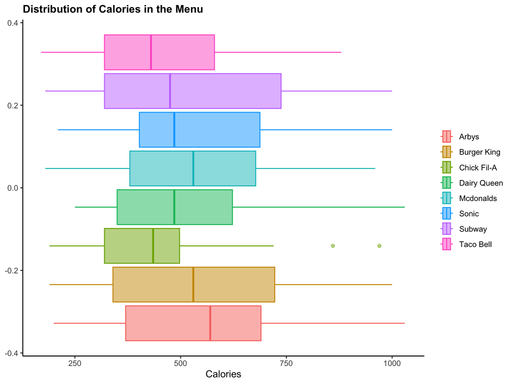

```r
ggplot(data = fastfood, mapping = aes(x = calories, color = restaurant, fill = restaurant)) +
       geom_boxplot(alpha = 0.5)+
       theme_classic()+
       scale_x_continuous(limits = quantile(fastfood$calories, c(0.05, 0.95))) +
       labs(x = "Calories", title = "Distribution of Calories in the Menu") +
       theme(plot.title = element_text(angle = 0, size = 12, face = "bold"))+
       theme(legend.title = element_blank())
```

# Statistical Inference

- Suppose we are interested on calculating the average calories of fast food items in this data set.
- We do it directly with the mean function.
- **Point Estimate:** 530.91 calories.

```r
mean(fastfood$calories, na.rm = TRUE)
```

```
## [1] 530.9126
```

- How can we know how reliable is this estimation? How likely is that if we take another sample of fast food items from other restaurants, we get a similar estimate for the average number of calories?
- **Objective:** estimate the value of population parameter $\mu$ (i.e. average number of calories of fast food items)
- **Method:** use sample average $\bar{x}$ as the **estimator** for the population parameter $\mu$.
- Let $x_1, x_2, ..., x_n$ be a random sample of observations (in our example, $x_i$ is the number of calories of fast food item $i$).
- **Central Limit Theorem** If $N$ is large enough, the statistic $\bar{x}$ follows a normal distribution with mean $\mu$ and standard deviation $\sigma$, where $\mu$ and $\sigma$ are the mean and standard deviation of the distribution where the sample comes from.
- To assess the sampling variation of the estimate we compute the standard errors.

**Standard Error**

$$\begin{equation}
SE_\bar{x} = \frac{\sigma_x}{\sqrt(n)}
\end{equation}$$

Where $\sigma_x$ is the standard deviation of and $n$ is the number of observations.

- Key intuition: as $n$ increases, the standard error decreases. As you add more observations to your sample, then the your estimates on the mean get more reliable.
- With the standard errors we can construct confidence intervals by calculating margin of errors.
- **Margin of Error**

$$\begin{equation}
ME = z^* \times SE(\bar{x})
\end{equation}$$

Where $z^*$ is percentile of the normal distribution correspondent to the confidence level chose for the interval.

To understand intuitively the percentile recall the definition. Let $Z$ be a standard normal random variable.

$$\begin{equation}
1-\alpha = Pr(-z^* < Z < z^*)
\end{equation}$$

Then, the definition of **Confidence Interval**

$$\begin{equation}
CI = (\bar{x} - M.E, \bar{x} + M.E)
\end{equation}$$

Let’s look at data. First, at the distribution of a standard normal random variable.

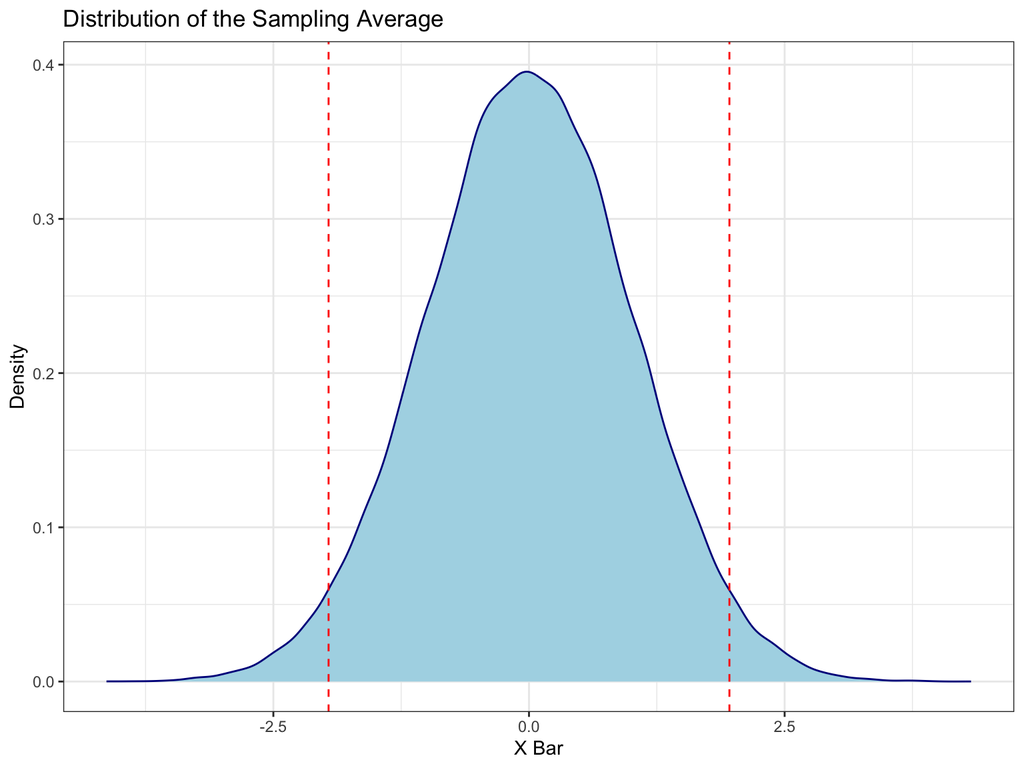

```r
set.seed(123)
n_samples <- 100000  # Number of random samples to generate
data <- data.frame(x = rnorm(n_samples))
lower_value <- qnorm(0.025, mean = 0, sd =1, lower.tail = TRUE)
upper_value <- qnorm(0.975, mean = 0, sd =1, lower.tail = TRUE)

## Ggplot
xbar_dist <- ggplot(data, aes(x = x)) +
             geom_density(color = "darkblue", fill = "lightblue") +
             geom_vline(xintercept = c(lower_value, upper_value), color = "red", linetype = "dashed")+
             theme_bw() +
             labs(title = "Distribution of the Sampling Average", x = "X Bar",y = "Density")
xbar_dist
```

# Statistical Inference: Example

```r
# Data
calories <- fastfood$calories
#Define the Statistics
calories_mean <-mean(calories, na.rm = TRUE)
calories_sd <-sd(calories, na.rm = TRUE)
calories_obs <- calories %>% na.omit() %>% length()
calories_se <- calories_sd / sqrt(calories_obs)
# Compute the Margin Error
margin_error <- calories_se*upper_value
# Compute the Confidence Interval
ci <- c(calories_mean - margin_error, calories_mean + margin_error)
ci <- paste("(",as.character(round(ci[1],4)),",",as.character(round(ci[2],4)), ")", sep="")
# Display Results
tibble(`Average Calories` = calories_mean,
           `Standard Error of the Mean` = calories_se,
           `Confidence Interval` = ci) %>%
  # code below is just for better visualization
  flextable() %>% autofit()
```

| Average Calories | Standard Error of the Mean | Confidence Interval |
| --- | --- | --- |
| 530.9126 | 12.44562 | (506.5196,555.3056) |

# Hypothesis Testing: One Sample T-test

- We can get the same output using the *t.test* function.
- One sample t-test: allows us to determine whether the mean ofa sample data set is different than a known value.

```r
t.test(calories, mu = 0)
```

```
##
##  One Sample t-test
##
## data:  calories
## t = 42.659, df = 514, p-value < 2.2e-16
## alternative hypothesis: true mean is not equal to 0
## 95 percent confidence interval:
##  506.4621 555.3632
## sample estimates:
## mean of x
##  530.9126
```

# Example: Average Calories by Restaurant

- 1. Compute the average calories per item for each restaurant, the standard error of the mean, and the confidence interval.
- How would you do it?
- One solution: group_by and summarize.

```r
calories_restaurant <- fastfood %>% group_by(restaurant) %>%
                                    summarize(mean = mean(calories, na.rm = TRUE),
                                              sd = sd(calories, na.rm = TRUE),
                                              obs = n()) %>%
                                    mutate(mean_se = sd/sqrt(obs)) %>%
                                    mutate(margin_error = qt(0.975,df=obs)*mean_se) %>%
                                    mutate(ci_low = mean - margin_error) %>%
                                    mutate(ci_high = mean + margin_error)

calories_restaurant %>%
    # code below is just for better visualization
  flextable() %>% autofit()
```

| restaurant | mean | sd | obs | mean_se | margin_error | ci_low | ci_high |
| --- | --- | --- | --- | --- | --- | --- | --- |
| Arbys | 532.7273 | 210.3388 | 55 | 28.36208 | 56.83888 | 475.8884 | 589.5662 |
| Burger King | 608.5714 | 290.4184 | 70 | 34.71164 | 69.23018 | 539.3412 | 677.8016 |
| Chick Fil-A | 384.4444 | 220.4948 | 27 | 42.43424 | 87.06787 | 297.3766 | 471.5123 |
| Dairy Queen | 520.2381 | 259.3377 | 42 | 40.01667 | 80.75692 | 439.4812 | 600.9950 |
| Mcdonalds | 640.3509 | 410.6961 | 57 | 54.39803 | 108.93018 | 531.4207 | 749.2811 |
| Sonic | 631.6981 | 300.8816 | 53 | 41.32927 | 82.89602 | 548.8021 | 714.5941 |
| Subway | 503.0208 | 282.2210 | 96 | 28.80406 | 57.17560 | 445.8452 | 560.1964 |
| Taco Bell | 443.6522 | 184.3449 | 115 | 17.19025 | 34.05057 | 409.6016 | 477.7027 |

- We can represent the estimates for the mean in a graph.

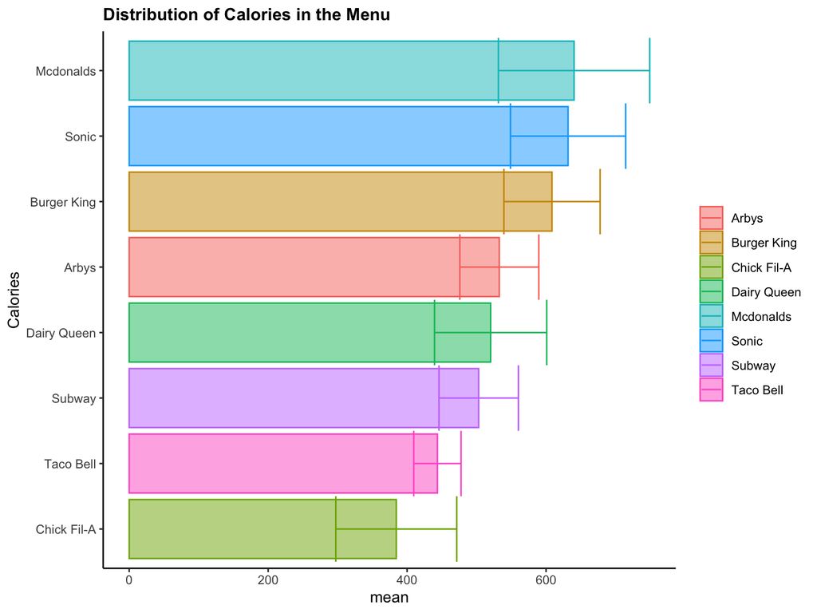

```r
calories_restaurant %>% ggplot(mapping = aes(x = reorder(restaurant, mean), y = mean, fill = restaurant, color = restaurant)) +
                        geom_bar(stat = "identity", alpha = 0.5) +
                        geom_errorbar(aes(ymin = ci_low, ymax = ci_high), width=1)+
                        coord_flip()+
                        labs(x = "Calories", title = "Distribution of Calories in the Menu") +
                        theme_classic()+
                        theme(plot.title = element_text(angle = 0, size = 12, face = "bold"))+
                        theme(legend.title = element_blank())
```

# Two Sample Hypothesis Test

- **Two Sample T-test:** used to compare one sample mean to another.
- Suppose we want to compare the average number of calories between two restaurants. Say we want to compare *Mcdonalds* and *Sonic*
- **Null Hypothesis:** Items from *Mcdonalds*, in average, have the same number of calories than items in restaurant *Sonic*.

$$\begin{equation*}
H_0: \bar{x}_m = \bar{x}_s
\end{equation*}$$

- **Alternative Hypothesis** Items from *Mcdonalds*, in average, have different number of calories than items in restaurant *Sonic*.

$$\begin{equation*}
H_a: \bar{x}_m \neq \bar{x}_s
\end{equation*}$$

- **Visual Intuition:** Let’s look at the distribution of calories at the items on the menu.

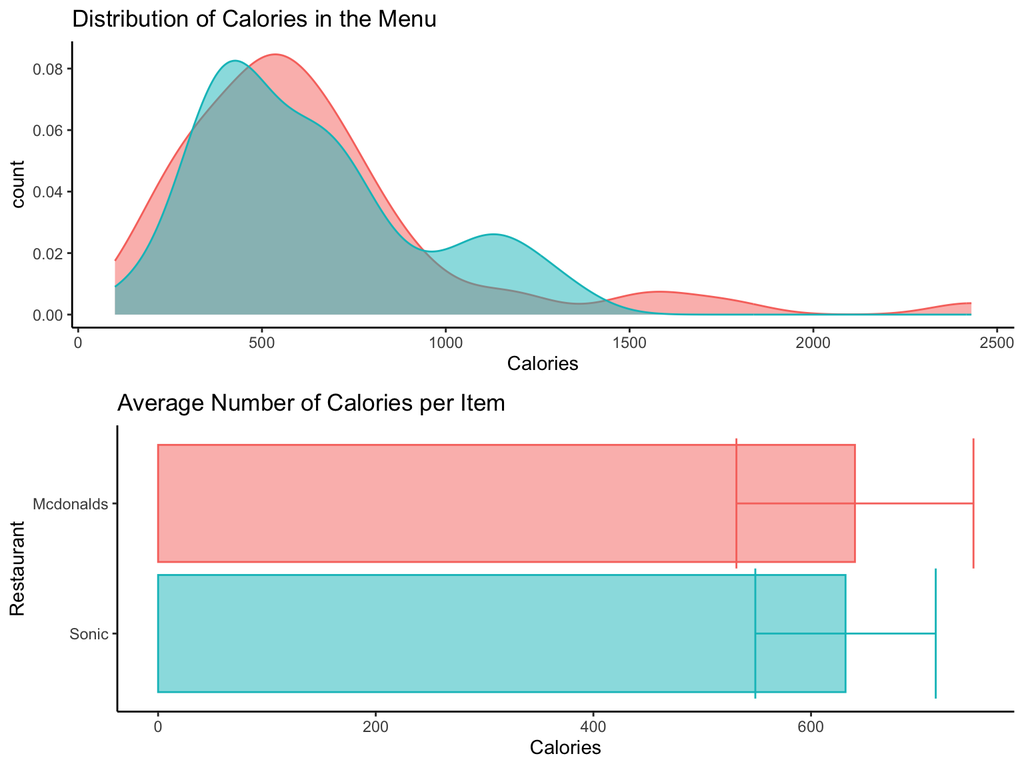

```r
mean_comparison <- calories_restaurant %>% filter(restaurant == "Mcdonalds" | restaurant == "Sonic") %>%
                                           ggplot(mapping = aes(x = reorder(restaurant, mean), y = mean, fill = restaurant, color = restaurant)) +
                                           geom_bar(stat = "identity", alpha = 0.5) +
                                           geom_errorbar(aes(ymin = ci_low, ymax = ci_high), width=1)+
                                           coord_flip() + # change x and y axis.
                                           theme_classic()+
                                           labs(x = "Restaurant", y = "Calories",
                                                title = "Average Number of Calories per Item")+
                                           theme(legend.position = "none")

dist_comparison <-fastfood %>% filter(restaurant == "Mcdonalds" | restaurant == "Sonic") %>%
                               ggplot(mapping = aes(x = calories, y = stat(count),
                                                    fill = restaurant, color = restaurant,
                                                    shape = restaurant)) +
                               geom_density(alpha = 0.5) +
                               theme_classic()+
                               theme(legend.position = "none")+
                               labs(x = "Calories", title = "Distribution of Calories in the Menu")

# Function to Format
cowplot::plot_grid(dist_comparison, mean_comparison, nrow = 2)
```

- Test statistic: mean difference between both samples: $t = \bar{x}_m - \bar{x}_s$
- Let’s estimate the hypothesis test comparing the mean from two independent samples.

```r
mcdonalds <- fastfood %>% filter(restaurant == "Mcdonalds") %>% select(calories)
sonic <- fastfood %>% filter(restaurant == "Sonic") %>% select(calories)
# test
test1 <- t.test(mcdonalds, sonic)
degfree <- test1$parameter
test1
```

```
##
##  Welch Two Sample t-test
##
## data:  mcdonalds and sonic
## t = 0.12666, df = 102.52, p-value = 0.8995
## alternative hypothesis: true difference in means is not equal to 0
## 95 percent confidence interval:
##  -126.8460  144.1515
## sample estimates:
## mean of x mean of y
##  640.3509  631.6981
```

- Small t-statistic == Large p-value == We cannot reject the null that both averages are the same across distributions.

-*Visual Representation of our draw from the distribution under the null hypothesis*

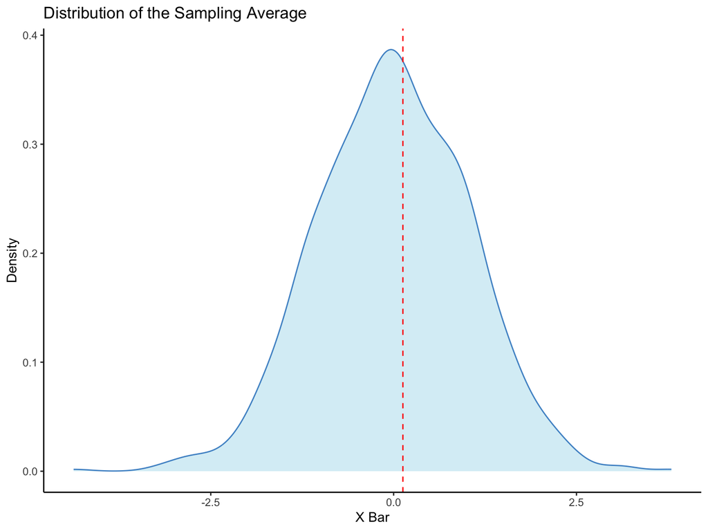

```r
# Compute the distribution of test-stastic under the null
t_dist_null <- data.frame(x = rt(n=1000, df =degfree)) %>% tibble()

## Ggplot
t_dist_plot <- ggplot(t_dist_null, aes(x = x)) +
               geom_density(color = "steelblue3", fill = "lightblue2", alpha = 0.5) +
               geom_vline(xintercept = test1$statistic, color = "red", linetype = "dashed")+
               theme_classic() +
               labs(title = "Distribution of the Sampling Average", x = "X Bar",y = "Density")
t_dist_plot
```

- This suggests that items from the menu of Mcdonalds and Sonic arguably come from the same distribution (i.e. the distribution of high-calorie burgers)

# Linear regression

- We are not going to cover what a regression is, the mechanics, etc.
- The goal is to demonstrate the R command so that you have a resource for when regressions are covered later in this course.
- This example: simple linear regression using the *gapminder* data.
- The gapminder data is part of the `gapminder` package, so we do not need the read.csv function:

```r
# For linear Regression example: load gapminder data
if(!require(gapminder)) {install.packages("gapminder")}
library(gapminder)
# Load data
gapminder=tibble(gapminder)
```

- Explore the dataset

```r
slice_sample(gapminder, n = 6)  %>%
# code below is just for better visualization
  tibble() %>% flextable() %>% autofit()
```

| country | continent | year | lifeExp | pop | gdpPercap |
| --- | --- | --- | --- | --- | --- |
| Comoros | Africa | 1,957 | 42.460 | 170,928 | 1,211.1485 |
| Mauritania | Africa | 1,992 | 58.333 | 2,119,465 | 1,361.3698 |
| Botswana | Africa | 1,982 | 61.484 | 970,347 | 4,551.1421 |
| Hungary | Europe | 2,007 | 73.338 | 9,956,108 | 18,008.9444 |
| Somalia | Africa | 2,002 | 45.936 | 7,753,310 | 882.0818 |
| Philippines | Asia | 1,987 | 64.151 | 60,017,788 | 2,189.6350 |

# Linear Regression Basics

- In R, a “formula” is denoted as “y ~ x” (similar to the “y = x”, just note that the tilde is used here).
- A multivariate regression (the variation in y depends on more than one variable) can be done by adding the additional variables to the formula (y ~ x + z, for example).
- The basic form of a simple linear regression is the following:

$$y_i = \alpha + \beta x_i +
e_i$$

- Example: What is the correlation between per capita income and life expectancy?
- *Dependent Variable:* life expectancy (measured in years)
- *Independent Variable:* natural log GDP per capita.
- Visual Intuition:

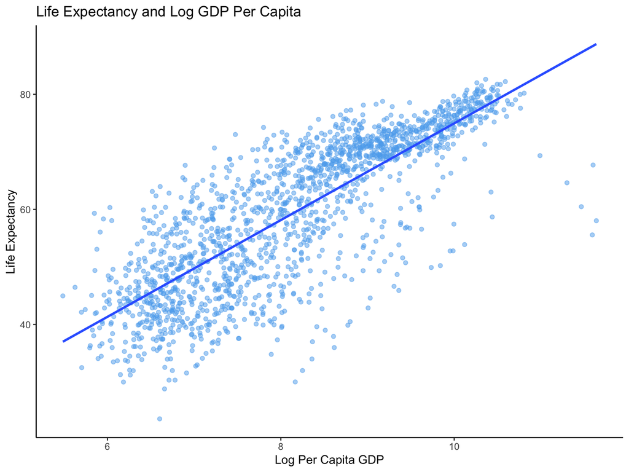

```r
# Create log GDP pc
gapminder <- gapminder %>%
  mutate(lngdppc = log(gdpPercap))

# Show plot with intuition of linear regression
gapminder %>%
  ggplot(mapping = aes(x=lngdppc, y = lifeExp))+
  geom_point(alpha = 0.5, col = "steelblue2") +
  geom_smooth(method = "lm", se = FALSE)+
  labs(x ="Log Per Capita GDP", y="Life Expectancy",
       title = "Life Expectancy and Log GDP Per Capita") +
  theme_classic()
```

- The relationship between *y* and *x* can be modeled by a straight line with some error *e*.
- Model Estimation:

```r
reg1 = lm(lifeExp ~ lngdppc, data = gapminder)
summary(reg1)
```

```
##
## Call:
## lm(formula = lifeExp ~ lngdppc, data = gapminder)
##
## Residuals:
##     Min      1Q  Median      3Q     Max
## -32.778  -4.204   1.212   4.658  19.285
##
## Coefficients:
##             Estimate Std. Error t value Pr(>|t|)
## (Intercept)  -9.1009     1.2277  -7.413 1.93e-13 ***
## lngdppc       8.4051     0.1488  56.500  < 2e-16 ***
## ---
## Signif. codes:  0 '***' 0.001 '**' 0.01 '*' 0.05 '.' 0.1 ' ' 1
##
## Residual standard error: 7.62 on 1702 degrees of freedom
## Multiple R-squared:  0.6522, Adjusted R-squared:  0.652
## F-statistic:  3192 on 1 and 1702 DF,  p-value: < 2.2e-16
```

- Interpretation: An increase in one unit in log GDP per capita, is associated with an increase of 8.4 years in life expectancy.
- This model allows you to predict values of life expectancy for given levels of GDP per capita.

```r
data.frame(reg1$model,
           PredictedLifeExpectancy= reg1$fitted.values,
           Residuals = reg1$residuals) %>%
           mutate(SquaredRes = Residuals^2) %>% arrange(by_group = SquaredRes) %>%
  head(n=10) %>%
  # code below is just for better visualization
  flextable() %>% autofit()
```

| lifeExp | lngdppc | PredictedLifeExpectancy | Residuals | SquaredRes |
| --- | --- | --- | --- | --- |
| 78.530 | 10.425987 | 78.53042 | -0.0004214746 | 0.0000001776408 |
| 49.190 | 6.936499 | 49.20098 | -0.0109777919 | 0.0001205119159 |
| 47.622 | 6.746695 | 47.60566 | 0.0163407861 | 0.0002670212896 |
| 51.821 | 7.250407 | 51.83940 | -0.0184005788 | 0.0003385812986 |
| 78.030 | 10.369468 | 78.05537 | -0.0253738420 | 0.0006438318576 |
| 68.700 | 9.261230 | 68.74054 | -0.0405357099 | 0.0016431437805 |
| 71.760 | 9.627020 | 71.81503 | -0.0550298524 | 0.0030282846506 |
| 75.370 | 10.056696 | 75.42649 | -0.0564918517 | 0.0031913293139 |
| 72.380 | 9.687021 | 72.31935 | 0.0606535427 | 0.0036788522391 |
| 44.600 | 6.381106 | 44.53285 | 0.0671492501 | 0.0045090217951 |

- The blue line in the graph above corresponds to the predicted life expectancy.
- Tip for intuition: for the simple linear regression model:

$$\beta_1 =
\frac{cov(x,y)}{var(x)}$$

- Regression coefficients capture the correlation of two variables, adjusting for the variance of the explanatory variable.

**Extra**

- Multivariate regression:

```r
reg2 = lm(lifeExp ~ lngdppc + year, data = gapminder)
summary(reg2)
```

```
##
## Call:
## lm(formula = lifeExp ~ lngdppc + year, data = gapminder)
##
## Residuals:
##      Min       1Q   Median       3Q      Max
## -27.2291  -3.8454   0.6065   4.7737  17.8644
##
## Coefficients:
##               Estimate Std. Error t value Pr(>|t|)
## (Intercept) -3.911e+02  1.942e+01  -20.14   <2e-16 ***
## lngdppc      7.770e+00  1.381e-01   56.27   <2e-16 ***
## year         1.956e-01  9.927e-03   19.70   <2e-16 ***
## ---
## Signif. codes:  0 '***' 0.001 '**' 0.01 '*' 0.05 '.' 0.1 ' ' 1
##
## Residual standard error: 6.877 on 1701 degrees of freedom
## Multiple R-squared:  0.7169, Adjusted R-squared:  0.7165
## F-statistic:  2153 on 2 and 1701 DF,  p-value: < 2.2e-16
```

# Diagnostic Plots after you run a regression

- After you run a regression, it is easy to see the diagnostic plots in R.
- Using the plot() command will return the Residuals v. Fitted, Normal Q-Q, Scale-Location, and Residuals v. Leverage plots.
- You need to run a regression and save the results (e.g., reg1 = lm(…)) because the saved results are the input for the plot() command.

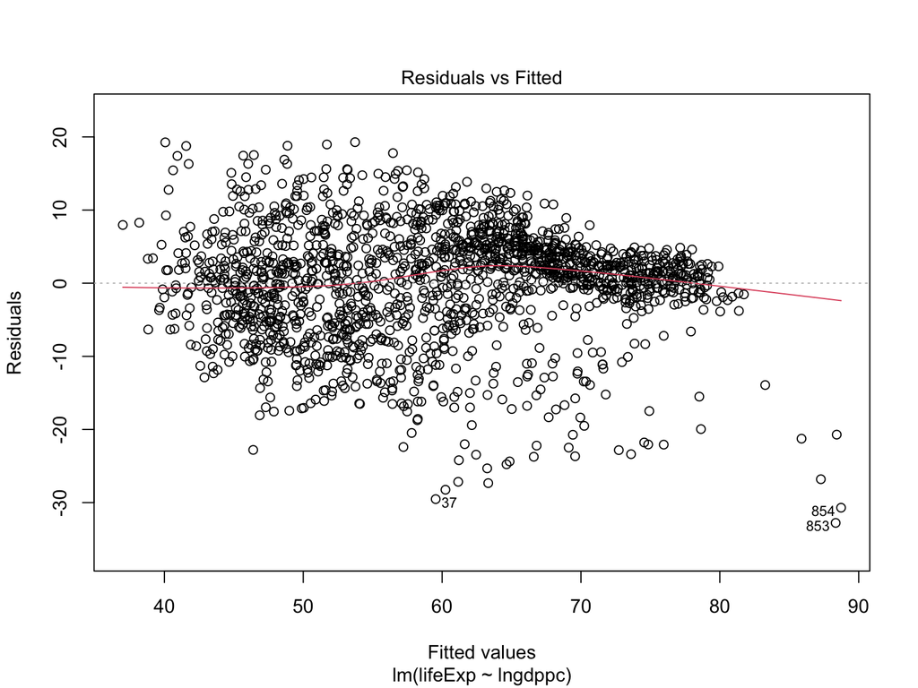

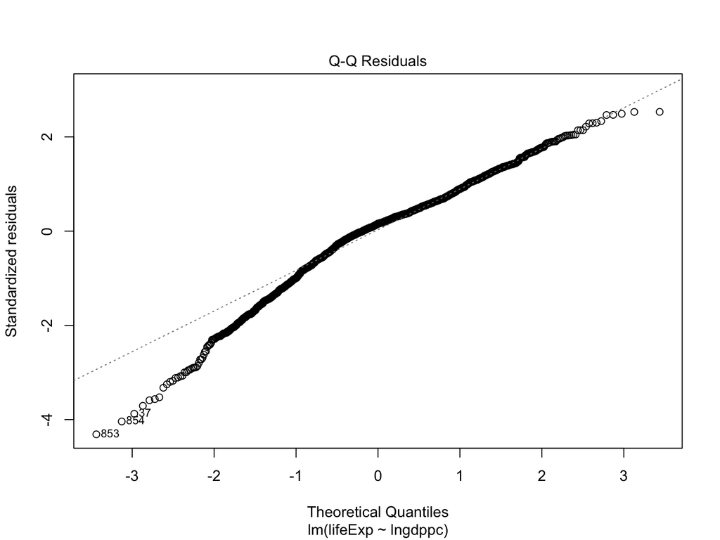

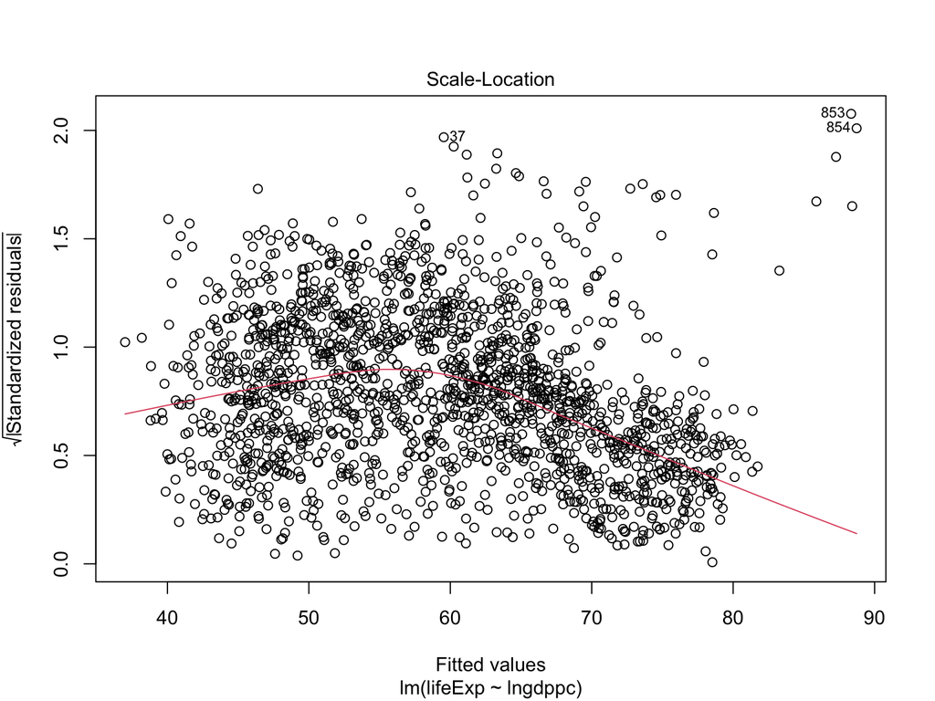

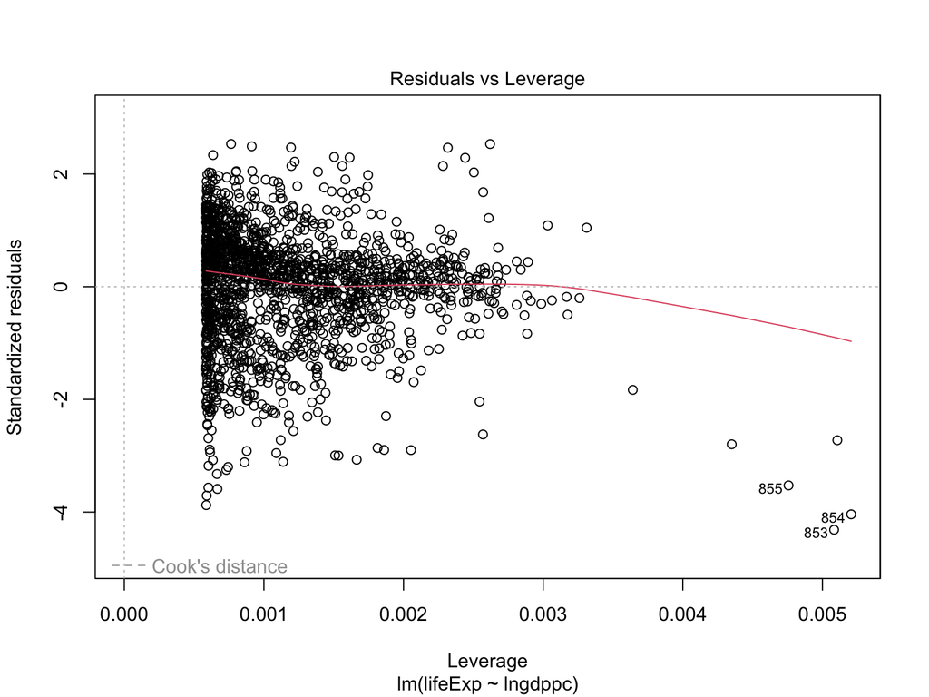

```r
plot(reg1)
```

- The residual plot shows that $\hat{e}_i$ appears to be scattered around zero, the dashed horizontal line. A sign that there are no nonlinear relationships not captured by the model.
- The normal QQ plot is used to visually assess the normality of the residuals (ideally points on the 45 degree line).
- The scale-location plot shows the spread of the residuals over the fitted values (a test of homoskedasticity).
- The residuals vs leverage plot allows you to detect influential observations or outliers that might change the results of the model significantly. These are the observations found *outside* of the Cook’s distance lines.

# ANOVA

- The Analysis of Variance (ANOVA) shows you the variation of the dependent variable broken into the variation of the regressors and the residuals.
- The ANOVA also reports the test statistic F that compares the mean squares from the independent variables (explained variation) and the mean squares from the error term (unexplained variation).

```r
aov_1 = aov(lifeExp ~ lngdppc, data = gapminder)
aov(reg1)
```

```
## Call:
##    aov(formula = reg1)
##
## Terms:
##                   lngdppc Residuals
## Sum of Squares  185334.83  98813.56
## Deg. of Freedom         1      1702
##
## Residual standard error: 7.619535
## Estimated effects may be unbalanced
```

```r
summary(aov_1)
```

```
##               Df Sum Sq Mean Sq F value Pr(>F)
## lngdppc        1 185335  185335    3192 <2e-16 ***
## Residuals   1702  98814      58
## ---
## Signif. codes:  0 '***' 0.001 '**' 0.01 '*' 0.05 '.' 0.1 ' ' 1
```

- The F value is equal to *Mean Sq LifeExp*/*Mean Sq Residuals*.
- If the null hypothesis is true, any differences between the explained and unexplained variation are due to chance, therefore, the mean squares shout be roughly the same.

```r
aov_2 = aov(lifeExp ~ lngdppc + year, data = gapminder)
summary(aov_2)
```

```
##               Df Sum Sq Mean Sq F value Pr(>F)
## lngdppc        1 185335  185335  3918.4 <2e-16 ***
## year           1  18359   18359   388.2 <2e-16 ***
## Residuals   1701  80454      47
## ---
## Signif. codes:  0 '***' 0.001 '**' 0.01 '*' 0.05 '.' 0.1 ' ' 1
```

**What else can you do with the ANOVA?**

- The sum of squares displayed in the ANOVA table allows you to compute the coefficient of determination ($R^2$), which is a measure of the variance in your outcome or dependent variable that is explained by the independent variable(s):

$$R^2 = 1 - SSR/SST$$
- Where $SSR$ is the sum of squared residuals and $SST$ is the total sum of squares.

- For example, in *reg1*, $R^2 = 0.652$. This means that 65% of the variation in life expectancy can be explained by the variation in GDP per capita (log).

$$R^2 = 1 - SSR/SST \Rightarrow 1 -
98814/(185335+98814) = 0.6522$$

# Extra: Mean Estimation using lm function

- Regression is way of computing conditional averages.

$$E[y |x] = \beta_0 + \beta_1
x$$

- Example: unconditional average
- Suppose you want to estimate the sample mean of life expectancy, and obtain the standard error, confidence interval, and p-value of the point estimate.
- We have covered how to do that with the *t.test* function.
- One sample t-test where the null hypothesis is equal to zero.

```r
t.test(gapminder$lifeExp, mu = 0)
```

```
##
##  One Sample t-test
##
## data:  gapminder$lifeExp
## t = 190.06, df = 1703, p-value < 2.2e-16
## alternative hypothesis: true mean is not equal to 0
## 95 percent confidence interval:
##  58.86070 60.08818
## sample estimates:
## mean of x
##  59.47444
```

- How is this related to linear regression?

$$E[y |x = 0] = \beta_0$$

- We can replicate this same calculation using the *lm* function to estimate a linear regression only using the intercept as explanatory variable.

```r
lm(formula = lifeExp ~ 1, data = gapminder) %>% summary()
```

```
##
## Call:
## lm(formula = lifeExp ~ 1, data = gapminder)
##
## Residuals:
##     Min      1Q  Median      3Q     Max
## -35.875 -11.276   1.238  11.371  23.129
##
## Coefficients:
##             Estimate Std. Error t value Pr(>|t|)
## (Intercept)  59.4744     0.3129   190.1   <2e-16 ***
## ---
## Signif. codes:  0 '***' 0.001 '**' 0.01 '*' 0.05 '.' 0.1 ' ' 1
##
## Residual standard error: 12.92 on 1703 degrees of freedom
```

# Extra: Regression Based Two Sample T-Test.

- Example: compare life expectancy between countries with high population and low population.
- First, create a dummy variable that splits the sample between countries above the median population observed in the data.

```r
median_pop <- median(gapminder$pop)
gapminder <- gapminder %>% mutate(large_pop = ifelse(pop > median_pop, "Large Population", "Small Population"))
```

- With *t.test* command we estimate a two sample t-test that compares the average life expectancy for countries with large population.

```r
# Store Samples Separately
large_pop <- gapminder %>% filter(large_pop == "Large Population") %>% select(lifeExp)
small_pop <- gapminder %>% filter(large_pop == "Small Population") %>% select(lifeExp)
```

- Run t.test function. Look at the t-stat, the confidence interval

```r
test <- t.test(large_pop, small_pop)
test
```

```
##
##  Welch Two Sample t-test
##
## data:  large_pop and small_pop
## t = 6.7429, df = 1681.7, p-value = 2.128e-11
## alternative hypothesis: true difference in means is not equal to 0
## 95 percent confidence interval:
##  2.954135 5.377697
## sample estimates:
## mean of x mean of y
##  61.55740  57.39148
```

- Mean Difference:

```r
mean_large = test$estimate[1]
mean_small = test$estimate[2]
mean_difference = mean_large - mean_small
mean_difference
```

```
## mean of x
##  4.165916
```

- With *lm* function we just run a regression the dummy variable that splits the sample.
- Note the coefficient on the dummy captures the mean difference between the two.

```r
lm(lifeExp ~ large_pop, data = gapminder) %>% summary()
```

```
##
## Call:
## lm(formula = lifeExp ~ large_pop, data = gapminder)
##
## Residuals:
##     Min      1Q  Median      3Q     Max
## -37.958 -11.265   1.014  10.922  24.817
##
## Coefficients:
##                           Estimate Std. Error t value Pr(>|t|)
## (Intercept)                61.5574     0.4369 140.907  < 2e-16 ***
## large_popSmall Population  -4.1659     0.6178  -6.743 2.12e-11 ***
## ---
## Signif. codes:  0 '***' 0.001 '**' 0.01 '*' 0.05 '.' 0.1 ' ' 1
##
## Residual standard error: 12.75 on 1702 degrees of freedom
## Multiple R-squared:  0.02602,    Adjusted R-squared:  0.02545
## F-statistic: 45.47 on 1 and 1702 DF,  p-value: 2.12e-11
```

- **NOTE** beware this interpretation is only valid for doing regression on dummy variables. With discrete and continuous variables intuition is similar but interpretation is slightly different.
- Useful to keep in mind the “calculus interpretation” of regression coefficients.

$$y = \beta_0 + \beta_1 x + e$$

$$\beta_1 = \frac{dy}{dx}$$

# Extra Example

- Let’s do the same, but now comparing Sonic and Chick Fil-A
- **Visual Intuition:** Let’s look at the distribution of calories at the items on the menu.
- **Tip:** Note this way you can write functions to format all your plots.

```r
format_plot <- function(graph, title, fontsize){
  # Format the Graph
  formatted_plot <- graph  +
           theme_classic() +
           labs(title = title)+
           theme(axis.text.x = element_text(angle = 0, size = fontsize)) +
           theme(axis.text.y = element_text(angle = 0, size = fontsize)) +
           theme(axis.title.x = element_text(size = fontsize)) +
           theme(axis.title.y = element_text(size = fontsize)) +
           theme(legend.text = element_text(size = fontsize -2))+
           theme(legend.title = element_blank())+
           theme(legend.position = "none") +
           theme(plot.title = element_text(angle = 0, size = fontsize + 3, face = "bold"))
  return(formatted_plot)
}
```

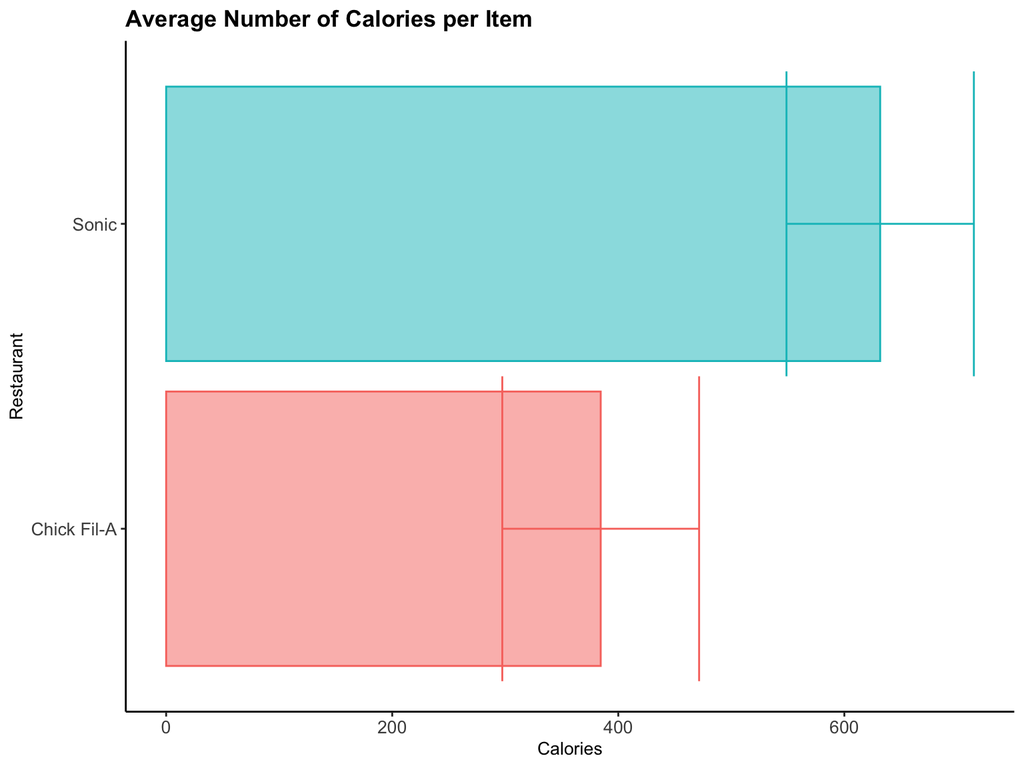

```r
mean_comparison <- calories_restaurant %>% filter(restaurant == "Sonic" | restaurant == "Chick Fil-A") %>%
                                           ggplot(mapping = aes(x = reorder(restaurant, mean), y = mean, fill = restaurant, color = restaurant)) +
                                           geom_bar(stat = "identity", alpha = 0.5) +
                                           geom_errorbar(aes(ymin = ci_low, ymax = ci_high), width=1)+
                                           coord_flip()+
                                           labs(x = "Restaurant", y = "Calories")+
                                           theme(legend.position = "none")
# Function to Format
mean_comparison <- format_plot(graph = mean_comparison, title = "Average Number of Calories per Item", fontsize = 10)

dist_comparison <-fastfood %>% filter(restaurant == "Sonic" | restaurant == "Chick Fil-A") %>%
                               ggplot(mapping = aes(x = calories, y = stat(count),
                                                    fill = restaurant, color = restaurant,
                                                    shape = restaurant)) +
                               geom_density(alpha = 0.5) +
                               theme_classic()+
                               theme(legend.position = "none")+
                               labs(x = "Calories")

# Function to Format
dist_comparison <- format_plot(graph = dist_comparison, title = "Distribution of Calories in the Menu", fontsize = 10)
mean_comparison
```

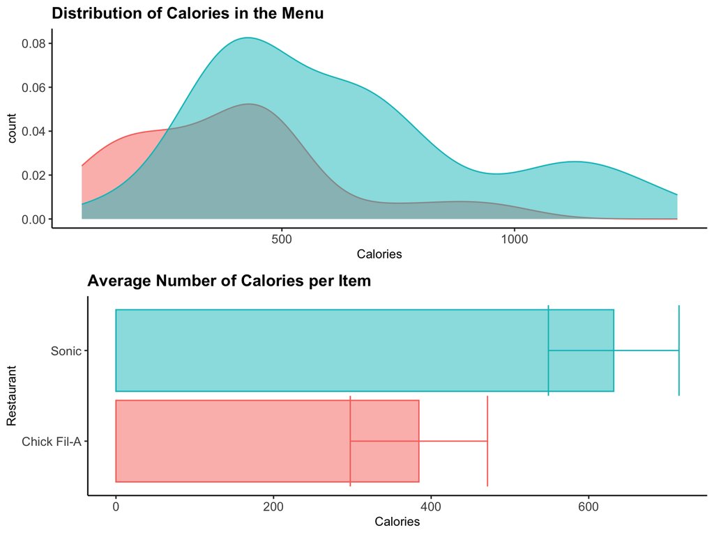

```r
plot_grid(dist_comparison, mean_comparison, nrow = 2)
```

- Let’s estimate the hypothesis test comparing the mean from two independent samples.

```r
chickfila <- fastfood %>% filter(restaurant == "Chick Fil-A") %>% select(calories)
# test
test2 <- t.test(sonic, chickfila)
degfree <- test2$parameter
test2
```

```
##
##  Welch Two Sample t-test
##
## data:  sonic and chickfila
## t = 4.1741, df = 68.089, p-value = 8.688e-05
## alternative hypothesis: true difference in means is not equal to 0
## 95 percent confidence interval:
##  129.0551 365.4523
## sample estimates:
## mean of x mean of y
##  631.6981  384.4444
```

-*Visual Representation of our draw from the distribution under the null hypothesis*

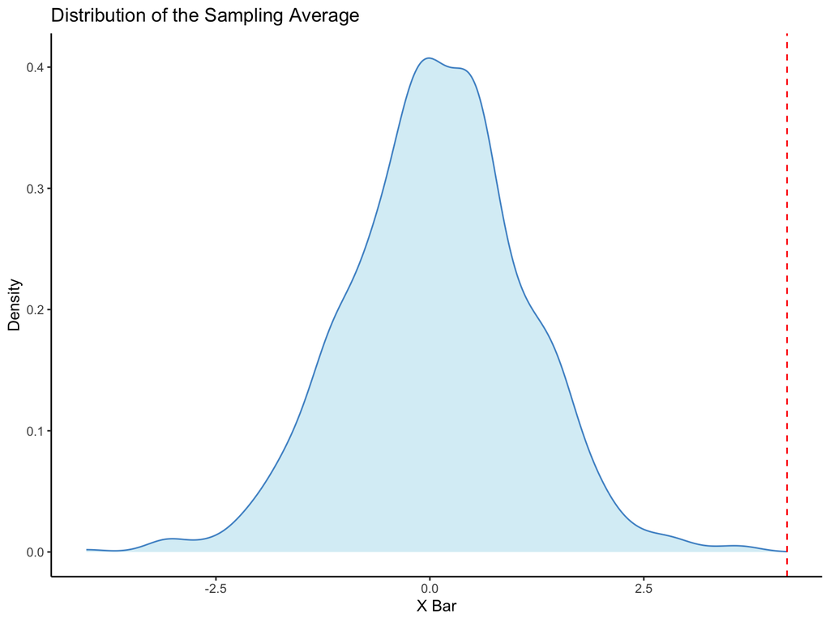

```r
# Compute the distribution of test-stastic under the null
t_dist_null <- data.frame(x = rt(n=1000, df =degfree)) %>% tibble()

## Ggplot
t_dist_plot <- ggplot(t_dist_null, aes(x = x)) +
               geom_density(color = "steelblue3", fill = "lightblue2", alpha = 0.5) +
               geom_vline(xintercept = test2$statistic, color = "red", linetype = "dashed")+
               theme_classic() +
               labs(title = "Distribution of the Sampling Average", x = "X Bar",y = "Density")
t_dist_plot
```

- Small p-value. We reject the null that both averages are the same across distributions.
- This suggests that items from the menu of Chick Fil-A come from a distribution (menu) with lower calories.